# Doublet Detection

Lauren Rylaarsdam

2025-07-07

Multiplets occur when two or more cells receive the same molecular identifier. High doublet rates can complicate analysis as they dilute cell type-specific methylation patterns. We have developed an approach for doublet removal by first simulating artificial doublets, constructing a Random Forest-based model to predict doublets, and removing cells from the original object exceeding the doublet score threshold.

The following vignette demonstrates how to apply this doublet removal approach using the brain vignette data.

## Loading libraries and example data

If you haven’t already, load necessary libraries.

```r
library(amethyst)
library(data.table)
library(ggplot2)
library(ggrepel)
library(dplyr)
library(tibble)
library(tidyr)
library(plyr)
library(cowplot)
library(harmony)
```

Next, download the example brain vignette data (this only needs to be done once; ignore if you went through the vignette).

```r
download.file("https://adeylabopen.s3.us-west-2.amazonaws.com/amethyst/brain_vignette_workspace.RData", "~/Downloads/brain_vignette_workspace.RData", method = "curl")
download.file("https://raw.githubusercontent.com/lrylaarsdam/amethyst/main/vignettes/brain_vignette/brain_vignette_cellInfo.txt", "~/Downloads/brain_vignette_cellInfo.txt")
download.file("https://raw.githubusercontent.com/lrylaarsdam/amethyst/main/vignettes/brain_vignette/brain_vignette.annot", "~/Downloads/brain_vignette.annot", method = "curl")
```

Build the object according to steps in the brain vignette to obtain cell type annotations. If you have already followed the brain vignette, this step can be skipped if the data is still in your work space.

```r
load("~/Downloads/brain_vignette_workspace.RData") # note metadata already added
obj@h5paths <- data.frame(barcode = rownames(obj@metadata),
                          path = rep("~/Downloads/brain_vignette.h5", length(rownames(obj@metadata))))
obj@metadata <- obj@metadata |> dplyr::filter(cov > 1000000 & mch_pct < 12)
set.seed(111)
obj@reductions[["irlba"]] <- runIrlba(obj, genomeMatrices = c("ch_100k_pct", "cg_100k_score"), dims = c(5, 5), replaceNA = c("mch_pct", 0))
set.seed(111)
obj@reductions[["irlba_regressed"]] <- regressCovBias(obj, reduction = "irlba")
set.seed(111)
obj <- runCluster(obj, k = 10, reduction = "irlba_regressed") # consider increasing k to 50 for larger datasets
```

```
##   Finding nearest neighbors...DONE ~ 0.001 s
##   Compute jaccard coefficient between nearest-neighbor sets...DONE ~ 0.001 s
##   Build undirected graph from the weighted links...DONE ~ 0.013 s
##   Run louvain clustering on the graph ...DONE ~ 0.002 s
##   Return a community class
##   -Modularity value: 0.6556388
##   -Number of clusters: 5
```

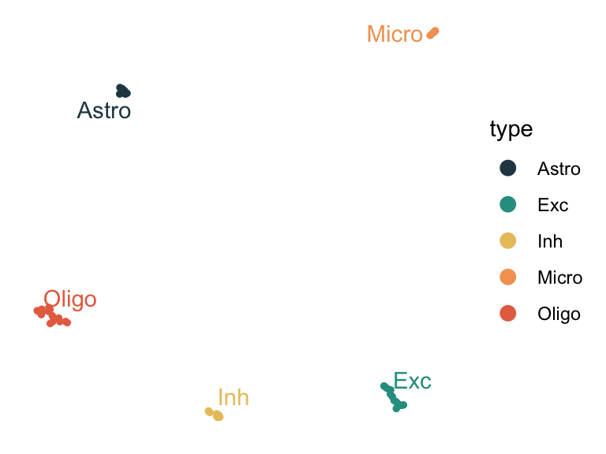

```r
set.seed(111)
obj@reductions[["umap"]] <- runUmap(obj, neighbors = 5, dist = 0.01, method = "euclidean", reduction = "irlba_regressed")
obj@metadata[["type"]] <- dplyr::recode(obj@metadata[["cluster_id"]],
                                        "1" = "Astro",
                                        "2" = "Exc",
                                        "3" = "Micro",
                                        "4" = "Oligo",
                                        "5" = "Inh")

# define colors
pal <- makePalette(option = 13, n = 5)

# plot
group_labels <- merge(obj@metadata, obj@reductions[["umap"]], by = 0) |> dplyr::group_by(type) |> dplyr::summarise(dim_x = mean(dim_x), dim_y = mean(dim_y))

dimFeature(obj, colorBy = type, colors = pal, pointSize = 1, reduction = "umap") +
  geom_text_repel(data = group_labels, aes(x = dim_x, y = dim_y, label = type))
```

## Doublet detection

First, we simulate a fraction of artificial doublets. Note that you may have to downsample large datasets to build the doublet model.

```r
# doublet calling
set.seed(123)
dbobj <- makeDoubletObject(obj, simFraction=0.30, threads = 1, genomeMatrices=c("cg_100k_score"))
```

```
## Adding doublet status info
## Adding additional metadata
## Processing matrix: cg_100k_score
```

```
## Completed matrix: cg_100k_score
## Adding matrix to new object: cg_100k_score
## Completed creating doublet object
```

Next, run IRLBA on the doublet-containing object.

```r
set.seed(123)
dbobj@reductions[["irlba"]] <- runIrlba(dbobj, genomeMatrices=c("cg_100k_score"), dims=c(5))
dbobj <- runCluster(dbobj, k = 10, reduction = "irlba") # consider increasing k to 50 for larger datasets
```

```
## Run Rphenograph starts:
##   -Input data of 65 rows and 5 columns
##   -k is set to 10
```

```
##   Finding nearest neighbors...DONE ~ 0.001 s
##   Compute jaccard coefficient between nearest-neighbor sets...DONE ~ 0.003 s
##   Build undirected graph from the weighted links...DONE ~ 0.004 s
##   Run louvain clustering on the graph ...DONE ~ 0.001 s
```

```
## Run Rphenograph DONE, totally takes 0.00899999999999679s.
```

```
##   Return a community class
##   -Modularity value: 0.7342459
##   -Number of clusters: 5
```

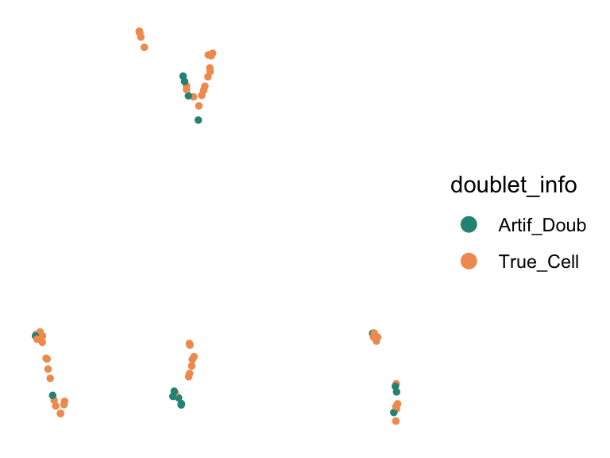

```r
dbobj@reductions[["umap"]] <- runUmap(dbobj, neighbors = 5, dist = 0.01, method = "euclidean", reduction = "irlba")
dimFeature(dbobj, colorBy = doublet_info, colors = c("#299388", "#F29C5F"), pointSize = 1)
```

Use the object containing simulated doublets to build a prediction model.

```r
set.seed(123)
result <- buildDoubletModel(dbobj = dbobj, method="rf", reduction = "irlba")
```

Use the module to predict doublet scores, then plot them with *geom_boxplot*.

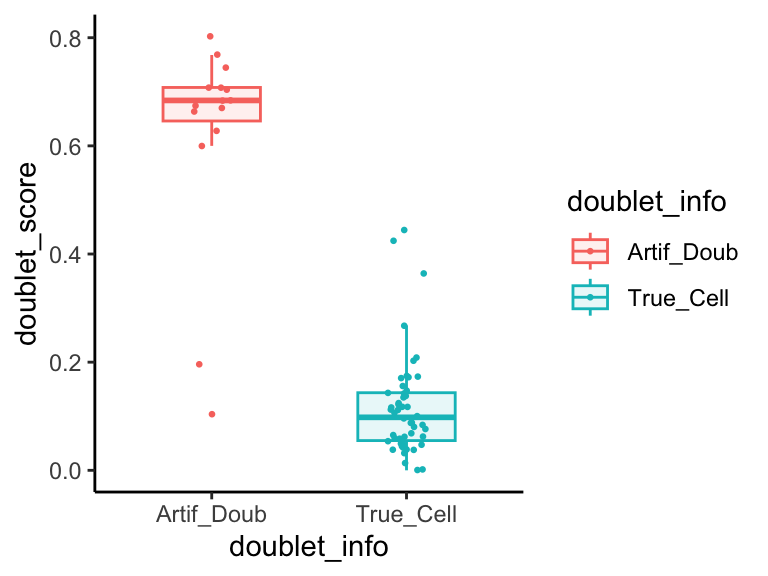

```r
set.seed(123)
dbobj <- predictDoubletScores(dbobj = dbobj, model = result$model, reduction = "irlba")
ggplot(dbobj@metadata, aes(x = doublet_info, y = doublet_score, color = doublet_info, fill = doublet_info)) +
  geom_boxplot(alpha = 0.1, outlier.size = 0, outlier.alpha = 0, width = 0.5) + geom_jitter(width = 0.1, size = 0.5) + theme_classic()
```

Notice the two artificial doublet outliers with a low doublet score. These doublets likely happened to be simulated from cells of the same type.

Based on this graph, an appropriate threshold is around 0.3. Next we add the doublet scores to the original object and filter cells with a value exceeding our threshold.

```r
obj <- addDoubletScores(obj, dbobj)

singlets <- rownames(obj@metadata[obj@metadata$doublet_score < 0.3, ])
singlets <- subsetObject(obj, cells = singlets)
```

Now re-do clustering without the doublets.

```r
set.seed(123)
singlets@reductions[["irlba"]] <- runIrlba(singlets, genomeMatrices=c("cg_100k_score"), dims=c(5))
singlets <- runCluster(singlets, k = 10, reduction = "irlba") # consider increasing k to 50 for larger datasets
```

```
## Run Rphenograph starts:
##   -Input data of 47 rows and 5 columns
##   -k is set to 10
```

```
##   Finding nearest neighbors...DONE ~ 0 s
##   Compute jaccard coefficient between nearest-neighbor sets...DONE ~ 0.002 s
##   Build undirected graph from the weighted links...DONE ~ 0.003 s
##   Run louvain clustering on the graph ...DONE ~ 0 s
```

```
## Run Rphenograph DONE, totally takes 0.004999999999999s.
```

```
##   Return a community class
##   -Modularity value: 0.6677077
##   -Number of clusters: 5
```

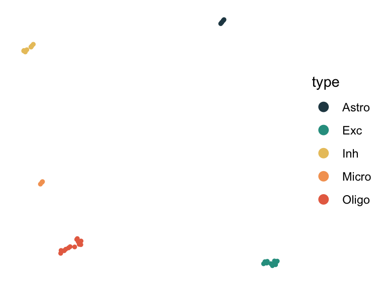

```r
singlets@reductions[["umap"]] <- runUmap(singlets, neighbors = 5, dist = 0.01, method = "euclidean", reduction = "irlba")
dimFeature(singlets, colorBy = type, colors = pal, pointSize = 1)
```

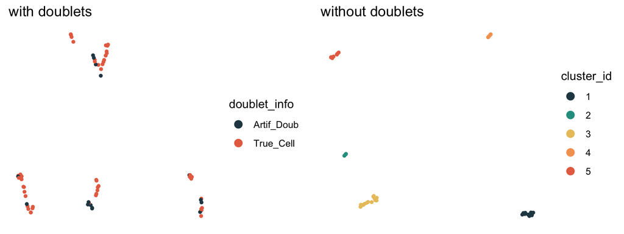

```r
plot_grid(dimFeature(dbobj, colorBy = doublet_info, colors = c("#264653", "#E76F51"), pointSize = 1) + ggtitle("with doublets"),
          dimFeature(singlets, colorBy = cluster_id, colors = c("#264653", "#2A9D8F", "#E9C46A", "#F4A261", "#E76F51"), pointSize = 1) + ggtitle("without doublets"))
```

We hope this helps! Feel free to reach out with any questions.